# IOS App Rating Modeling & Analysis

Group 4B Yuhong Lu, Xiaohan Mei, Ziyan Pei,Peng Yuan, Mengqing Zhang, Jiayuan Zou

Oct 15th 2019

### Load packages and environment

### Data Cleaning

```r
ap_omit <- read_csv('AP_omit.csv')
# Remove the '+' in `cont_rating` column so that the data
# could be read by r
ap_omit$cont_rating <- str_replace(ap_omit$cont_rating, "[+]", "")
# change the class of variables in order to generate matrix and model for the further use
ap_omit$vpp_lic <- as.factor(ap_omit$vpp_lic)
ap_omit$cont_rating <- as.numeric(ap_omit$cont_rating)
ap_omit$prime_genre <- as.factor(ap_omit$prime_genre)
```

### Descriptive Statistics

##### Distribution of Categories

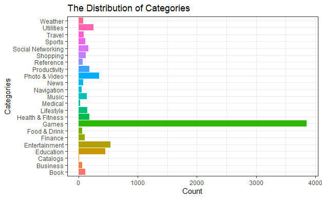

```r
ggplot(data=ap_omit) +
  geom_bar(aes(x=prime_genre, fill=prime_genre),show.legend = FALSE)+
  labs(x = "Categories", y = "Count",
        title = "The Distribution of Categories")+
  coord_flip() + theme_bw()
```

This bar chart shows how many number of the apps are stored in the apple store and what categories they belowed to. It can tell us what’s the majority apps that people are used right now, and what kind of apps will attract people to download.

##### Distribution of User Rating

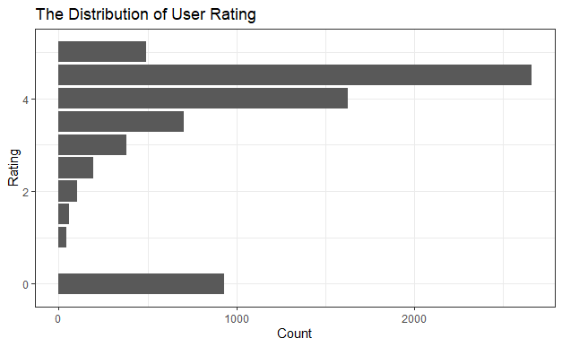

```r
ggplot(data=ap_omit) +
  geom_bar(aes(x=user_rating),show.legend = FALSE)+
  labs(x = "Rating", y = "Count",
        title = "The Distribution of User Rating")+
  coord_flip() + theme_bw()
```

This bar chart shows the distribution of user rating. When we are using the apps, based on whether if we enjoyed its function, we can give ratings from one to five, and in this chart, we can tell, how many people gives out what kind of ratings.

##### Categories VS Average Rating(descending)

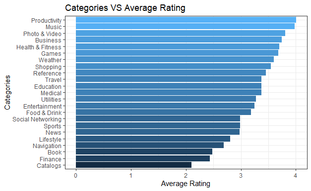

```r
avg_categ <- ap_omit%>%
  group_by(prime_genre)%>%
  summarise(average_rating = mean(user_rating))%>%
  arrange(desc(average_rating))

ggplot(data = avg_categ, aes(reorder(prime_genre, average_rating), y = average_rating, fill = average_rating))+
  geom_bar(stat = "identity", show.legend = FALSE)+
  labs (x = "Categories", y = "Average Rating",
        title = "Categories VS Average Rating") +
  coord_flip()
```

The Categories VS Average Rating shows in each specific category what rate people usually give out. For example, the productivty and music category are the top two categories which get almost four out of five points. And catelogs are the lowest category that only get a little bit over two points.

##### Categories VS Average Rating(number of)

```r
rating_cate <- ap_omit%>%
   group_by(prime_genre)%>%
  summarize(average_rating = mean(user_rating, na.rm = TRUE),
            rating_count = sum(rating_count_tot, na.rm = TRUE)) %>%
   print
```

| prime_genre | average_rating | rating_count |
| --- | --- | --- |
| Book | 2.477679 | 574049 |
| Business | 3.745614 | 272921 |
| Catalogs | 2.100000 | 17325 |
| Education | 3.376380 | 1014371 |
| Entertainment | 3.245318 | 4030339 |
| Finance | 2.432692 | 1148956 |
| Food & Drink | 3.182540 | 878133 |
| Games | 3.684047 | 52872546 |
| Health & Fitness | 3.700000 | 1784371 |
| Lifestyle | 2.805556 | 887294 |

[output cut: 13 more lines]

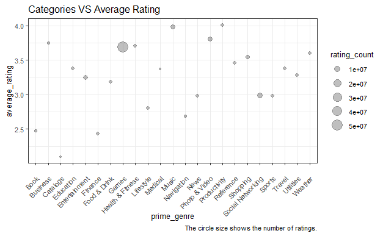

```r
ggplot(data = rating_cate, mapping = aes(x = prime_genre, y = average_rating)) +
  geom_point(aes(size = rating_count), alpha = 1/4) +
  labs(title = "Categories VS Average Rating",
       caption = "The circle size shows the number of ratings.") +
  theme(text = element_text(size = 10),
      axis.text.x = element_text(angle = 45, hjust = 1, vjust = 0.8))
```

This chart also shows the relationship between categories and user rating but in a more visual way. The circle size shows the number of ratings and if the size is large and up high means this category gets lots of good ratings.

##### The Distribution of Categories by Type(Free and Paid)

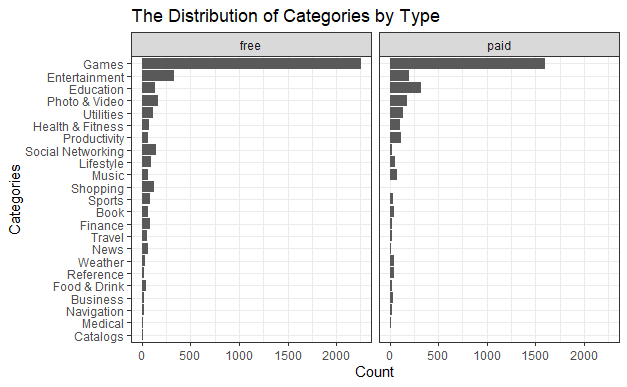

```r
type_count_cate <- ap_omit%>%
  mutate(type=ifelse(price==0,"free","paid"))%>%
  group_by(type,prime_genre)%>%
  summarise(count=n())

ggplot(data=type_count_cate,aes(reorder(prime_genre,count),y=count)) +
  geom_bar(stat = "identity") +
  labs (x="Categories", y="Count",
        title="The Distribution of Categories by Type") +
  coord_flip() +
  facet_wrap(~type)
```

There are free and paid two different type of apps in the apple store, and this chart analyze the number of free and paid apps in different categories. We can tell game related apps occupied huge number of the market share and the second will be entertainment apps while the least is catalog apps.

##### The Distribution of User Rating VS Categories by Type(Free and Paid)

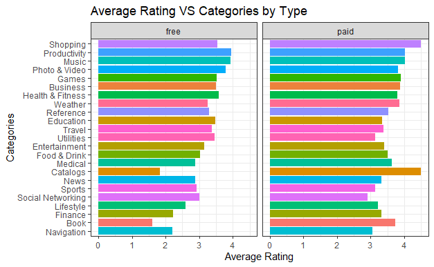

```r
type_rating_cate <- ap_omit%>%
  mutate(type = ifelse(price == 0, "free", "paid"))%>%
  group_by(type, prime_genre)%>%
  summarise(average_rating = mean(user_rating))

ggplot(data = type_rating_cate, aes(reorder(prime_genre, average_rating), y = average_rating)) +
  geom_bar(stat = "identity",aes(fill=prime_genre),show.legend = F) +
  labs (x = "Categories", y = "Average Rating",
        title = "Average Rating VS Categories by Type") +
  coord_flip() +
  facet_wrap(~type)
```

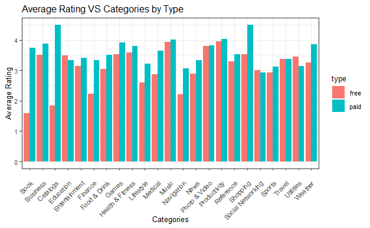

```r
ggplot(data = type_rating_cate, aes(x = prime_genre, y = average_rating, fill=type))+
  geom_bar(stat = "identity", position = position_dodge())+
  labs (x = "Categories", y = "Average Rating",
        title = "Average Rating VS Categories by Type")+
  theme(text = element_text(size=10),
        axis.text.x = element_text(angle=45,hjust=1,vjust=0.8))
```

This chart shows the same relationship as the previous one but in a different version. It put the free and paid apps of the same category side by side and mark the free and paid apps into two different colors. It would be more obvious to analyze the relationship different variables.

### Test and Train data split

```r
# this is needed to create reproducible results,
# otherwise your random split will be different each time you run the code
set.seed(12345)
# This will split into train and test 70-30
ap_omit$train <- sample(c(0, 1), nrow(ap_omit), replace = TRUE, prob = c(.3, .7))
ap_test <- ap_omit %>% filter(train == 0)
ap_train <- ap_omit %>% filter(train == 1)
y_train <- ap_train$user_rating
y_test <- ap_test$user_rating
```

###### Create the variable that we use

In this project, we want to predict how the rating for a specific APP would be given 9 independent variables. Therefore, we set up `user_rating` as our dependent variable; 9 independent variables that we adopted are `price`, `rating_count_tot` (the number of ratings for an App), `cont_rating` (content rating), `sup_devices.num` (number of supporting devices), `size_bytes` (the size of app in bytes), `prime_genre` (the category of the app), `ipadSc_urls.num`(Number of screenshots showed for display), `lang.num` (Number of supported languages), and `vpp_lic`(Vpp Device Based Licensing Enabled,1 means APP uses device-based liscence, 0 means APP uses apple-id based liscence).

```r
f1 <- as.formula(user_rating~ price + rating_count_tot +
                   cont_rating +sup_devices.num +size_byte+
                  prime_genre+ipadSc_urls.num+lang.num+vpp_lic)
```

### Linear Regression without cross validation

```r
ap_lm <- lm(f1, ap_train)
yhat_train_lm <- predict(ap_lm)
mse_train_lm <- mean((y_train - yhat_train_lm)^2)
yhat_test_lm <- predict(ap_lm, ap_test)
mse_test_lm <- mean((y_test - yhat_test_lm)^2)
coef(ap_lm)
```

```
                 (Intercept)
                1.497873e+00
                       price
                7.241523e-03
            rating_count_tot
                1.341094e-06
                 cont_rating
               -1.348505e-02
             sup_devices.num
               -1.064893e-02
                   size_byte
                1.199909e-10
         prime_genreBusiness
                8.506596e-01
         prime_genreCatalogs
               -6.184893e-01
        prime_genreEducation
                5.356894e-01
    prime_genreEntertainment
                8.071965e-01
          prime_genreFinance
                3.263427e-01
     prime_genreFood & Drink
                9.553925e-01
            prime_genreGames
                1.029728e+00
 prime_genreHealth & Fitness
                1.393644e+00
        prime_genreLifestyle
                5.647699e-01
          prime_genreMedical
                6.147764e-01
            prime_genreMusic
                1.236721e+00
       prime_genreNavigation
                3.924685e-01
             prime_genreNews
                8.150043e-01
    prime_genrePhoto & Video
                1.242851e+00
     prime_genreProductivity
                1.216735e+00
        prime_genreReference
                8.102167e-01
         prime_genreShopping
                1.359421e+00
prime_genreSocial Networking
                7.622821e-01
           prime_genreSports
                7.559700e-01
           prime_genreTravel
                8.160684e-01
        prime_genreUtilities
                8.437295e-01
          prime_genreWeather
                8.707539e-01
             ipadSc_urls.num
                1.743684e-01
                    lang.num
                2.265787e-02
                    vpp_lic1
                7.543220e-01
```

```r
mse_train_lm
```

```
[1] 2.02616
```

```r
mse_test_lm
```

```
[1] 1.986448
```

We first tried to use the linear regression without cross validation, and get the train and test mse, but we found that the test mse is less then the train mse, then we try to use the cross validation to get a better result.

### Linear regression with cross validation

```r
set.seed(12345)

ap_folds <- createFolds(ap_train$user_rating, k = 10)
k <- length(ap_folds)
lmmse <- data.frame()
model <- list()
for(i in 1 : k){
  train.data <- ap_train[-ap_folds[[i]], ]
  valid.data <- ap_train[ap_folds[[i]], ]
  train_y <- y_train[-ap_folds[[i]]]
  valid_y <- y_train[ap_folds[[i]]]
  model[[i]] <- lm(f1, train.data)
  y_train_hat <- predict(model[[i]], train.data)
  y_valid_hat <- predict(model[[i]], valid.data)
  lmmse[i, 1] <- mean((y_train_hat - train_y) ^ 2)
  lmmse[i, 2] <- mean((y_valid_hat - valid_y) ^ 2)
}
names(lmmse) <- c('Train.MSEs', 'Valid.MSEs')
lmmse.min.index <- which.min(lmmse$Valid.MSEs)
lmmse[lmmse.min.index, ]
```

|  | Train.MSEs | Valid.MSEs |
| --- | --- | --- |
| 5 | 2.050166 | 1.823457 |

```r
mse_test <- mean((predict(model[[lmmse.min.index]], ap_test) - ap_test$user_rating) ^ 2)
mse_test
```

```
[1] 1.983673
```

```r
summary(model[[lmmse.min.index]])
```

```
Call:
lm(formula = f1, data = train.data)

Residuals:
    Min      1Q  Median      3Q     Max
-4.3128 -0.2746  0.4001  0.8386  3.4453

Coefficients:
                               Estimate Std. Error
(Intercept)                   1.742e+00  4.133e-01
price                         7.312e-03  3.913e-03
rating_count_tot              1.333e-06  3.006e-07
cont_rating                  -1.508e-02  5.186e-03
sup_devices.num              -1.109e-02  6.057e-03
size_byte                     9.416e-11  6.680e-11
prime_genreBusiness           8.931e-01  3.103e-01
prime_genreCatalogs          -9.860e-01  6.121e-01
prime_genreEducation          5.437e-01  1.960e-01
prime_genreEntertainment      7.790e-01  1.916e-01
prime_genreFinance            2.418e-01  2.432e-01
prime_genreFood & Drink       9.779e-01  3.024e-01
prime_genreGames              1.026e+00  1.775e-01
prime_genreHealth & Fitness   1.388e+00  2.185e-01
prime_genreLifestyle          5.321e-01  2.282e-01
prime_genreMedical            7.380e-01  4.363e-01
prime_genreMusic              1.251e+00  2.283e-01
prime_genreNavigation         3.874e-01  3.121e-01
prime_genreNews               7.944e-01  2.701e-01
prime_genrePhoto & Video      1.232e+00  2.017e-01
prime_genreProductivity       1.265e+00  2.285e-01
prime_genreReference          8.793e-01  2.805e-01
prime_genreShopping           1.323e+00  2.383e-01
prime_genreSocial Networking  7.390e-01  2.252e-01
prime_genreSports             6.619e-01  2.454e-01
prime_genreTravel             8.593e-01  2.789e-01
prime_genreUtilities          8.751e-01  2.103e-01
prime_genreWeather            9.958e-01  2.753e-01
ipadSc_urls.num               1.729e-01  1.219e-02
lang.num                      2.184e-02  2.745e-03
vpp_lic1                      5.501e-01  2.782e-01
```

[output cut: 24 more lines]

```
prime_genreSocial Networking   3.282 0.001037 **
prime_genreSports              2.697 0.007021 **
prime_genreTravel              3.081 0.002077 **
prime_genreUtilities           4.160 3.24e-05 ***
prime_genreWeather             3.617 0.000301 ***
ipadSc_urls.num               14.184  < 2e-16 ***
lang.num                       7.955 2.25e-15 ***
vpp_lic1                       1.977 0.048050 *
---
Signif. codes:
0 ‘***’ 0.001 ‘**’ 0.01 ‘*’ 0.05 ‘.’ 0.1 ‘ ’ 1

Residual standard error: 1.437 on 4507 degrees of freedom
Multiple R-squared:  0.1266,    Adjusted R-squared:  0.1208
F-statistic: 21.78 on 30 and 4507 DF,  p-value: < 2.2e-16
```

In this section, we use Cross Validation to train the better Linear Regression Model. By using the For Loop, we can split the training data into 10 folds and using each of the fold for training the model. As the result, we can got a model with the lowest validation MSE = 1.823. Then we got the testing MSE = 1.984, which is near to the validation MSE, means that the model is not overfitting.

### Shrinkage Analysis

Use ridge and lasso model get mse, then compare mse to compare the models. ### Ridge

```r
x1_train <- model.matrix(f1, ap_train)[, -1]
x1_test <- model.matrix(f1, ap_test)[, -1]
ap_ridge <- cv.glmnet(x1_train, y_train, alpha = 0, nfolds = 10)
coef(ap_ridge)
```

```
31 x 1 sparse Matrix of class "dgCMatrix"
                                         1
(Intercept)                   2.982447e+00
price                         3.964596e-03
rating_count_tot              7.300481e-07
cont_rating                  -8.711897e-03
sup_devices.num              -6.860408e-03
size_byte                     8.869838e-11
prime_genreBusiness          -6.322355e-03
prime_genreCatalogs          -6.846062e-01
prime_genreEducation         -1.198654e-01
prime_genreEntertainment     -8.813053e-02
prime_genreFinance           -3.617269e-01
prime_genreFood & Drink      -6.265676e-02
prime_genreGames              1.102607e-01
prime_genreHealth & Fitness   1.881990e-01
prime_genreLifestyle         -2.419812e-01
prime_genreMedical           -1.657166e-01
prime_genreMusic              1.729305e-01
prime_genreNavigation        -2.679581e-01
prime_genreNews              -1.044540e-01
prime_genrePhoto & Video      1.528310e-01
prime_genreProductivity       1.832259e-01
prime_genreReference         -1.527038e-02
prime_genreShopping           1.326129e-01
prime_genreSocial Networking -1.447516e-01
prime_genreSports            -1.223468e-01
prime_genreTravel            -7.085027e-02
prime_genreUtilities         -6.608569e-02
prime_genreWeather           -1.895399e-02
ipadSc_urls.num               8.119122e-02
lang.num                      1.210451e-02
vpp_lic1                      4.173206e-01
```

```r
yhat_train_ridge <- predict(ap_ridge, x1_train, s = ap_ridge$lambda.min)
mse_train_ridge <- mean((y_train - yhat_train_ridge)^2)
yhat_test_ridge <- predict(ap_ridge,x1_test,s=ap_ridge$lambda.min)
mse_test_ridge <- mean((y_test-yhat_test_ridge)^2)
mse_train_ridge
```

```
[1] 2.030358
```

```r
mse_test_ridge
```

```
[1] 1.984174
```

### Lasso

```r
ap_lasso <- cv.glmnet(x1_train, y_train, alpha = 1, nfolds = 10)
yhat_train_lasso <- predict(ap_lasso, x1_train, s = ap_lasso$lambda.min)
yhat_test_lasso <- predict(ap_lasso,x1_test,s=ap_lasso$lambda.min)
mse_train_lasso <- mean((y_train - yhat_train_lasso)^2)
mse_test_lasso <- mean((y_test-yhat_test_lasso)^2)
coef(ap_lasso)
```

```
31 x 1 sparse Matrix of class "dgCMatrix"
                                         1
(Intercept)                   2.788989e+00
price                         .
rating_count_tot              5.321534e-07
cont_rating                  -1.925995e-03
sup_devices.num               .
size_byte                     .
prime_genreBusiness           .
prime_genreCatalogs           .
prime_genreEducation         -6.028150e-02
prime_genreEntertainment      .
prime_genreFinance           -1.147490e-01
prime_genreFood & Drink       .
prime_genreGames              5.578546e-02
prime_genreHealth & Fitness   1.098305e-01
prime_genreLifestyle          .
prime_genreMedical            .
prime_genreMusic              .
prime_genreNavigation         .
prime_genreNews               .
prime_genrePhoto & Video      6.647378e-02
prime_genreProductivity       .
prime_genreReference          .
prime_genreShopping           .
prime_genreSocial Networking  .
prime_genreSports             .
prime_genreTravel             .
prime_genreUtilities          .
prime_genreWeather            .
ipadSc_urls.num               1.643147e-01
lang.num                      1.829998e-02
vpp_lic1                      .
```

```r
mse_train_lasso
```

```
[1] 2.026193
```

```r
mse_test_lasso
```

```
[1] 1.985956
```

### Tree - Regression Tree

```r
#Regression tree
 fit.tree <- rpart(f1,
 ap_train,
 control = rpart.control(cp = 0.001))
 par(xpd = TRUE)

## Printcp will tell you what the cp of spliting into diffrent number layer and the xerror and xstd of each cp.
printcp(fit.tree)
```

```
Regression tree:
rpart(formula = f1, data = ap_train, control = rpart.control(cp = 0.001))

Variables actually used in tree construction:
[1] ipadSc_urls.num  prime_genre      rating_count_tot
[4] size_byte

Root node error: 11709/5042 = 2.3222

n= 5042

         CP nsplit rel error  xerror      xstd
1 0.7992540      0   1.00000 1.00048 0.0241363
2 0.0143084      1   0.20075 0.20088 0.0067002
3 0.0096168      2   0.18644 0.18954 0.0063237
4 0.0036879      3   0.17682 0.17799 0.0058148
5 0.0027723      4   0.17313 0.17559 0.0057384
6 0.0015818      5   0.17036 0.17362 0.0056416
7 0.0011615      6   0.16878 0.17457 0.0057007
8 0.0011338      9   0.16529 0.17490 0.0057321
9 0.0010000     10   0.16416 0.17496 0.0057327
```

```r
## use the following method to choose the cp with the smallest xerror
fit.tree$cptable[which.min(fit.tree$cptable[,"xerror"]),"CP"]
```

```
[1] 0.001581791
```

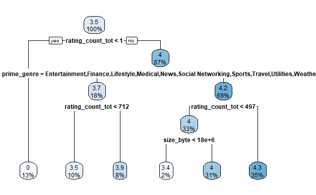

```r
## Build the tree model with the cp which has smallest xerror
tree2 <- prune(fit.tree, cp= fit.tree$cptable[which.min(fit.tree$cptable[,"xerror"]),"CP"])
## Make the visuallization of regreesion tree
rpart.plot(tree2)
```

```r
## MSE of train
tree.pred.train = predict(tree2,ap_train)
mean((tree.pred.train-ap_train$user_rating)^2)
```

```
[1] 0.3956153
```

```r
## MSE of test
tree.pred.test = predict(tree2,ap_test)
mean((tree.pred.test-ap_test$user_rating)^2)
```

```
[1] 0.39381
```

```r
printcp(tree2)
```

```
Regression tree:
rpart(formula = f1, data = ap_train, control = rpart.control(cp = 0.001))

Variables actually used in tree construction:
[1] prime_genre      rating_count_tot size_byte

Root node error: 11709/5042 = 2.3222

n= 5042

         CP nsplit rel error  xerror      xstd
1 0.7992540      0   1.00000 1.00048 0.0241363
2 0.0143084      1   0.20075 0.20088 0.0067002
3 0.0096168      2   0.18644 0.18954 0.0063237
4 0.0036879      3   0.17682 0.17799 0.0058148
5 0.0027723      4   0.17313 0.17559 0.0057384
6 0.0015818      5   0.17036 0.17362 0.0056416
```

After prune useing tge cp with smallest xerror, we can find that the variables acatually used in tree construction is `prime_genre`,`rating_count_tot` and `size_byte`. The MSE of train is 0.3956153 and the MSE of test is 0.39381.

### Random Forest

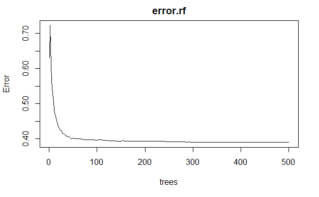

```r
#decide ntree by the plot of error vs ntree
error.rf <- randomForest(f1, data = ap_omit , subset = (1:nrow(ap_omit))[ap_omit$train==1])
plot(error.rf)
```

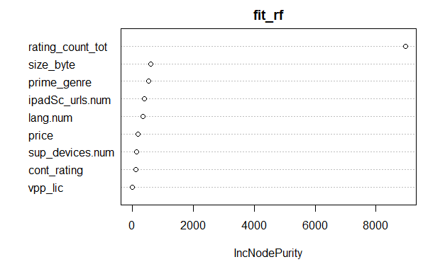

```r
fit_rf <- randomForest(f1,
                       ap_train,
                       ntree=300,
                       do.trace=F)

varImpPlot(fit_rf)
```

```r
yhat_rf <- predict(fit_rf, ap_train)
train_mse_rf <- mean((yhat_rf - ap_train$user_rating) ^ 2)
print(train_mse_rf)
```

```
[1] 0.1044315
```

```r
yhat_rf <- predict(fit_rf, ap_test)
test_mse_rf <- mean((yhat_rf - ap_test$user_rating) ^ 2)
print(test_mse_rf)
```

```
[1] 0.3684317
```

The importance of variables plot shows important variables that are ordered from top to bottom as most-to-least important. Therefore, the most important variables are at the top, which is `rating_count_tot`. Other 3 important variables are `size_byte`, `prime_genre` and `ipadSc_urls.num`.

### Boosting

```
 GBM STEP - version 2.9

Performing cross-validation optimisation of a boosted regression tree model
for user_rating and using a family of gaussian
Using 5042 observations and 9 predictors
creating 10 initial models of 50 trees

 folds are unstratified
total mean deviance =  2.3222
tolerance is fixed at  0.0023
ntrees resid. dev.
50    1.1038
now adding trees...
100   0.6558
150   0.4904
200   0.4282
250   0.4045
300   0.3956
350   0.392
400   0.3902
450   0.3889
500   0.3879
550   0.3874
600   0.387
650   0.3867
700   0.3865
750   0.3864
800   0.3862
850   0.3862
900   0.3862
950   0.3863
1000   0.3864
1050   0.3866
1100   0.3868
1150   0.3869
1200   0.3871
1250   0.3873

mean total deviance = 2.322
mean residual deviance = 0.338

estimated cv deviance = 0.386 ; se = 0.015

training data correlation = 0.925
cv correlation =  0.913 ; se = 0.004

elapsed time -  0.02 minutes
```

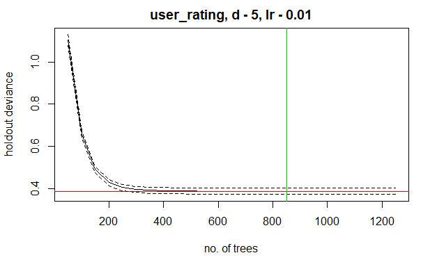

```r
# Use gbm.step function in dismo package to fit the boosting model
library(dismo)
# first, generate a train dataset for use
ap_train2 <- subset(ap_train,select = c('price','rating_count_tot','cont_rating',
                                    'sup_devices.num','size_byte','prime_genre',
                                    'ipadSc_urls.num','lang.num','vpp_lic','user_rating'))
ap_train2 <- as.data.frame(ap_train2)
# train boosting model, with learning.rate =0.01
# use full train dataset
fit_btree <- gbm.step(data=ap_train2, gbm.x =1:9,
                      gbm.y = 10, tree.complexity = 5,
                      family='gaussian',learning.rate = 0.01,
                      bag.fraction = 1)
```

```r
#relevant significance of variables
relative.influence(fit_btree,n.trees=750)
```

```
           price rating_count_tot      cont_rating
        874.6409      481149.1837         313.6160
 sup_devices.num        size_byte      prime_genre
        545.2724        3740.8882       12835.7813
 ipadSc_urls.num         lang.num          vpp_lic
       1139.4292        1315.7101           0.0000
```

```r
#calculate train and test mse
yhat_btree <- predict(fit_btree, ap_train, n.trees = 750)
mse_btree <- mean((yhat_btree - y_train) ^ 2)
yhat_btree_test <- predict(fit_btree,ap_test,n.trees=750)
mse_btree_test <- mean((yhat_btree_test-y_test)^2)
print(mse_btree)
```

```
[1] 0.3412437
```

```r
print(mse_btree_test)
```

```
[1] 0.3679166
```

### Summary

For overall analysis, the model with the lowest MSE for validation set is boosting. However, considering the level of interpretability, we may adopt the tree model, whose MSE is slightly higher than boosting, when we have audience who have no technical background. The biggest challenge we faced is to create k-fold cross validation for linear regression and choose the number of trees that should be used for boosting by gbm.step. The lessons that we have learned that could be put into practice in the future is that for machine learning model, the trade-off between interpretability and flexibility is very important. Depends on our audience and the business context/academic context, we should adopt different models - since right now we do not have a perfect model that is both ideal for interpretability and flexibility.